# Übungen zu Korrelation

Lukas Stammler

2023-02-09

# Übung 1

## Aufgabe

Entscheiden Sie für jede der sechs Grafiken, ob ein starker, moderater oder schwacher Zusammenhang zwischen den Variablen besteht und ob ein lineares Modell gültig ist.

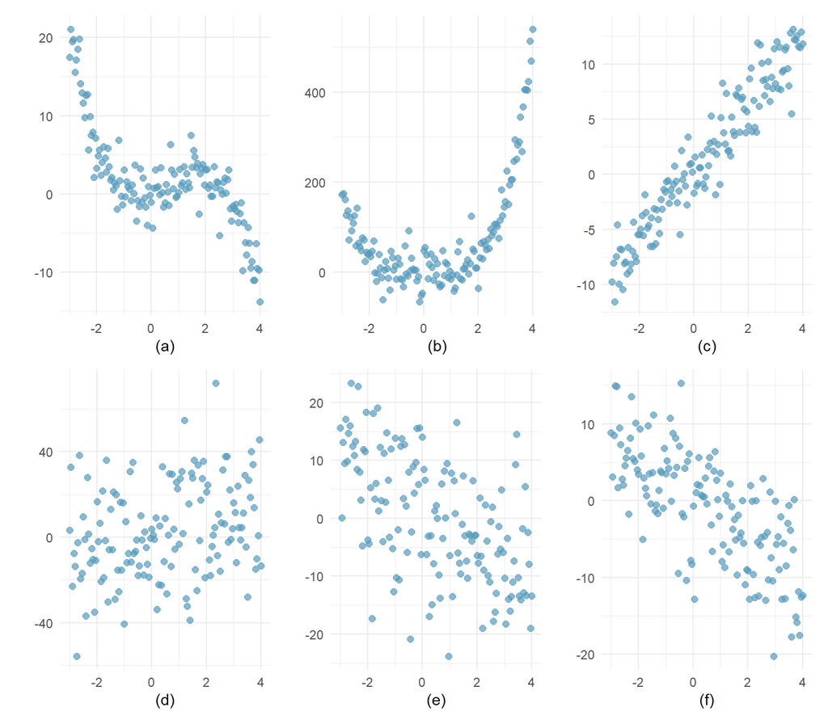

## Lösung

# Übung 2

## Aufgabe

Das Great Britain Office of Population Census and Surveys sammelte einst Daten aus einer Zufallsstichprobe von verheirateten Paaren. Erfragt wurden Alter und Körpergrösse von Ehegattin und Ehegatten.

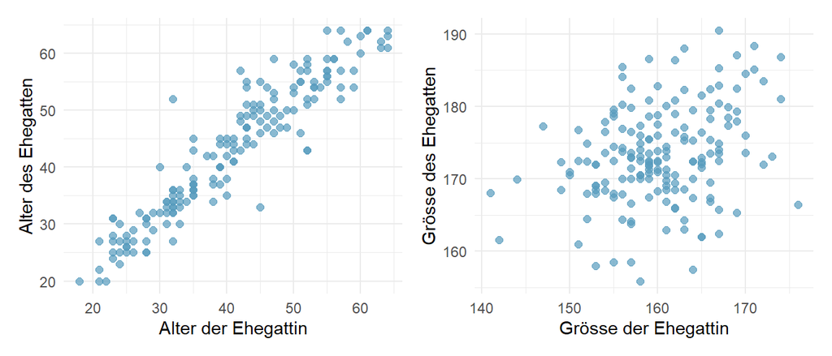

1. Beschreiben Sie den Zusammenhang zwischen dem Alter von Ehegattin und Ehegatten.
2. Beschreiben Sie den Zusammenhang zwischen der Körpergrösse von Ehegattin und Ehegatten.
3. Welche Grafik zeigt eine stärkere Korrelation? Begründen Sie ihre Antwort.

## Lösung

1. Der Zusammenhang zwischen dem Alter von Mann und Frau ist stark, positiv und linear.
2. Der Zusammenhang zwischen der Körpergrösse von Mann und Frau ist schwach aber positiv.
3. Das Alter zwischen den Ehepartnern korreliert stärker (r = 0.939) als Körpergrösse (r = 0.306). Begründung Die Punkte im Altersplot streuen weniger um eine gedachte Gerade als die Punkte im Plot zur Körpergrösse.

# Übung 3

## Aufgabe

Welcher Korrelationskoeffizient nach Pearson passt zu welcher Grafik?

1. r = -0.7
2. r = 0.45
3. r = 0.06
4. r = 0.92

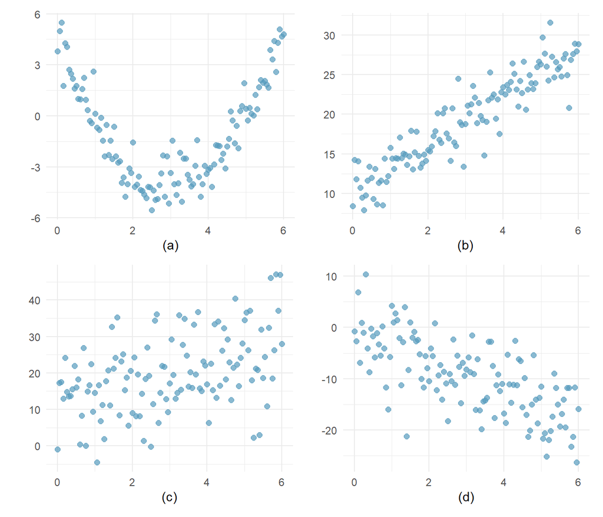

## Lösung

Plot a) r = 0.06, nicht linearer Zusammenhang  
Plot b) r = 0.92, stark positiv linearer Zusammenhang  
Plot c) r = 0.45, moderat positiv linearer Zusammenhang  
Plot d) r = -0.7, moderat negativ linearer Zusammenhang

# Übung 4

Besteht ein Zusammenhang zwischen Körpergrösse und Schuhgrösse bei den Physiotherapie-Studierenden. Arbeiten Sie mit dem Datensatz `physio.csv` bzw. `physio.omv`, den Sie bereits früher erstellt haben.

## Aufgabe

0. Laden Sie den Datensatz `physio.csv` bzw. `physio.omv` in **jamovi**.
1. Formulieren Sie Ihre Hypothesen.
2. Beschreiben Sie die interessierenden Variablen deskriptiv inkl. Grafik
3. Führen Sie eine Korrelationsanalyse durch.
4. Interpretieren Sie ihr Resultat.

## Lösung

1. Formulieren Sie Ihre Hypothesen.
- $H_0: \rho = 0$: Es besteht kein Zusammenhang zwischen Schuhgrösse und Körpergrösse.
- $H_A: \rho \neq 0$: Es besteht ein Zusammenhang zwischen Schuhgrösse und Körpergrösse.
2. Beschreiben Sie die interessierenden Variablen deskriptiv inkl. Grafik.
- Deskriptive Statistik: **jamovi** > Register *Analyses* > *Exploration* > *Descriptives* > `Groesse` und `Schuhgroesse` in *Variables*
- Streudiagramm: **jamovi** > Register *Analyses* > *Exploration* > *Scatterplot* > `Groesse` in *X-Axis*, `Schuhgroesse` in *Y-Axis*

```
##
##  DESCRIPTIVES
##
##  Descriptives
##  ──────────────────────────────────────────────────
##                          Groesse     Schuhgroesse
##  ──────────────────────────────────────────────────
##    N                          228             228
##    Missing                      0               0
##    Mean                  169.4781        39.27193
##    Median                168.0000        39.00000
##    Standard deviation    7.764397        2.448717
##    Minimum               148.0000        35.00000
##    Maximum               198.0000        48.00000
##  ──────────────────────────────────────────────────
```

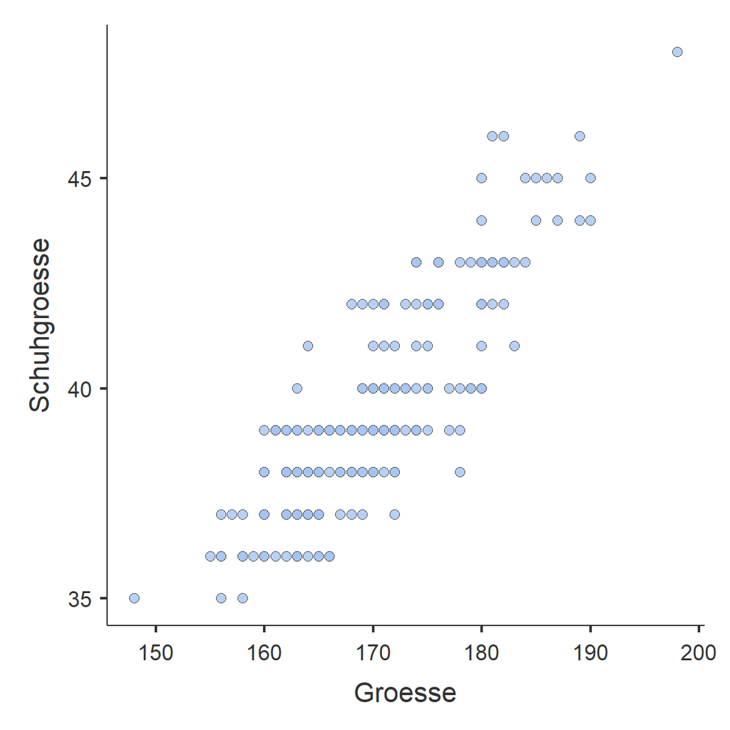

3. Führen Sie eine Korrelationsanalyse durch.
- **jamovi** > Register *Regression* > *Correlation Matrix* > `Groesse` und `Schuhgroesse` als Variablen auswählen > *Correlation Coefficients* > Häkchen bei *Pearson* setzen > *Additional Options* > Häkchen bei *Report significance* und *Confidence intervals* setzen.

```
##
##  CORRELATION MATRIX
##
##  Correlation Matrix
##  ──────────────────────────────────────────────────────────────
##                                    Groesse       Schuhgroesse
##  ──────────────────────────────────────────────────────────────
##    Groesse         Pearson's r              —
##                    p-value                  —
##                    95% CI Upper             —
##                    95% CI Lower             —
##
##    Schuhgroesse    Pearson's r      0.8545966               —
##                    p-value         < .0000001               —
##                    95% CI Upper     0.8861315               —
##                    95% CI Lower     0.8151841               —
##  ──────────────────────────────────────────────────────────────
```

4. Interpretieren Sie ihr Resultat.
- **Geprüft wurde der Zusammenhang zwischen Körpergrösse und Schuhgrösse. Die Korrelationsanalyse ergab einen moderat bis starken positiven Zusammenhang zwischen Körpergrösse und Schuhgrösse, $p$ = .85 [.8152, .8861], p < .0001.**
- Hinweis zu Interpretation von $p$-Wert und 95%-CI: Das 95%-CI beinhaltet den Nullwert nicht, womit $\rho = 0$ ein nicht plausibler Korrelationskoeffizient ist. Auch der p-Wert von <0.05 besagt, dass sich der Korrelationskoeffizient signifikant von 0 unterscheidet.

# Übung 5

Um Zusammenhänge richtig zu interpretieren, ist es wichtig, stets als Erstes die Grafiken anzuschauen. Um dies zu illustrieren, analysieren wir den Datensatz `anscombe.csv`. Dieser besteht aus 4 x-y-Kombinationen (x1-y1, x2-y2 etc) die alle die gleichen statistischen Merkmale (Mittelwert, Standardabweichung, Korrelationskoeffizient nach Pearson etc. aufweisen) und trotzdem völlig unterschiedlich sind.

Laden Sie den Datensatz `anscombe.csv` in **jamovi**.

## Aufgabe

0. Laden Sie den Datensatz `anscombe.csv` in **jamovi**. Sie müssen die `x1` - `x4`-Variablen in jamovi als *continuous-integer* kategorisieren.
1. Berechnen Sie Mittelwert und Standardabweichung für jede Variable. Was fällt Ihnen auf?
2. Berechnen Sie die Korrelationskoeffizienten nach Pearson $p$ für die 4 x-y-Paare.
3. Erstellen Sie für jedes x-y-Paar eine Grafik.

## Lösung

1. Berechnen Sie Mittelwert und Standardabweichung für jede Variable. Was fällt Ihnen auf?
- **jamovi** > Register *Analyses* > *Exploration* > *Descriptives* > Alle Variablen `x1` - `y4` als *Variables* auswählen.

```
##
##  DESCRIPTIVES
##
##  Descriptives
##  ──────────────────────────────────────────────────────────────────────────────────────────────────────────────────────
##                          x1          x2          x3          x4          y1          y2          y3          y4
##  ──────────────────────────────────────────────────────────────────────────────────────────────────────────────────────
##    N                           11          11          11          11          11          11          11          11
##    Mean                  9.000000    9.000000    9.000000    9.000000    7.500909    7.500909    7.500000    7.500909
##    Standard deviation    3.316625    3.316625    3.316625    3.316625    2.031568    2.031657    2.030424    2.030579
##  ──────────────────────────────────────────────────────────────────────────────────────────────────────────────────────
```

- Die `x`-Variablen haben alle den gleichen Mittelwert 9 und die gleiche Standardabweichung 3.32.
- Die `y`-Variablen haben alle den gleichen Mittelwert 7.5 und die gleiche Standardabweichung 2.03.
2. Berechnen Sie die Korrelationskoeffizienten nach Pearson für die vier x-y-Paare.
- Erstellen Sie eine Korrelationsmatrix mit allen x- und y-Variablen. Lesen Sie den Korrelationskoeffizienten für die zusammengehörenden Paare `x1-y1`, `x2-y2`, `x3-y3` und `x4-y4` ab.
- **jamovi** > Register *Analyses* > *Regression* > *Correlation Matrix* > Alle Variablen `x1` - `y4` als *Variables* auswählen > *Correlation Coefficients* > *Pearson* auswählen > in der angezeigten Korrelations-Matrix die Korrelationskoeffizienten für die zusammengehörenden Paare ablesen.

```
##
##  CORRELATION MATRIX
##
##  Correlation Matrix
##  ─────────────────────────────────────────────────────────────────────────────────────────────────────────────────────
##          x1            x2            x3            x4            y1            y2            y3            y4
##  ─────────────────────────────────────────────────────────────────────────────────────────────────────────────────────
##    x1             —
##    x2     1.0000000             —
##    x3     1.0000000     1.0000000             —
##    x4    -0.5000000    -0.5000000    -0.5000000             —
##    y1     0.8164205     0.8164205     0.8164205    -0.5290927             —
##    y2     0.8162365     0.8162365     0.8162365    -0.7184365     0.7500054             —
##    y3     0.8162867     0.8162867     0.8162867    -0.3446610     0.4687167     0.5879193             —
##    y4    -0.3140467    -0.3140467    -0.3140467     0.8165214    -0.4891162    -0.4780949    -0.1554718            —
##  ─────────────────────────────────────────────────────────────────────────────────────────────────────────────────────
```

| Paar | $r$ |
| --- | --- |
| x1-y1 | .8164 |
| x2-y2 | .8162 |
| x3-y3 | .8163 |
| x4-y4 | .8165 |

- Bis auf die 3. Stelle nach dem Komma sind alle Korrelationskoeffizienten gleich und weisen auf einen starken Zusammenhang hin.
3. Erstellen Sie für jedes x-y-Paar eine Grafik.
- Variante 1: Gleiche Einstellungen wie oben und unter *Plot* > Häkchen bei *Correlation Matrix* setzen. Die ausgegebenen Grafiken sind relativ klein und schlecht lesbar. Besser, aber etwas aufwändiger ist …
- Variante 2: **jamovi** > Register *Analyses* > *Exploration* > *Scatterplot* > `x1` in X-Axis und `y1` in Y-Axis einfügen, *Regression Line* > Häkchen bei *Linear*. Das Gleiche für die übrigen drei Datenpaare `x2-y2`, `x3-y3` und `x4-y4` wiederholen.

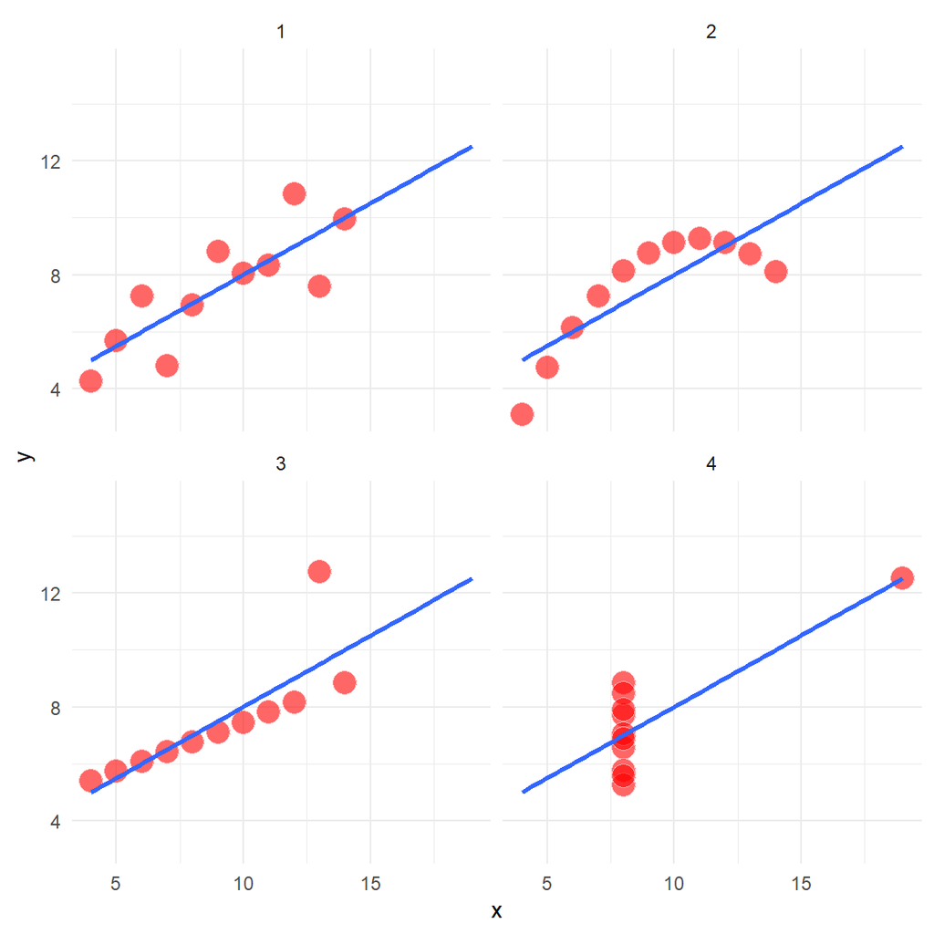

1. Das erste Datenpaar `x1-y1` entspricht recht gut einem linearen Zusammenhang.
2. Das zweite Datenpaar `x2-y2` zeigt keinen linearen Zusammenhang.
3. Das dritte Datenpaar `x3-y3` zeigt einen Ausreisser, der nicht mit einem linearen Modell vereinbar ist.
4. Das vierte Datenpaar `x4-y4`zeigt ebenfalls ein Muster, das nicht mit einem linearen Modell vereinbar ist.
- *Was lernen wir daraus? Ein Korrelationskoeffizient alleine kann keine Aussage zur Art eines Zusammenhangs machen. Wir müssen ihn immer im Zusammenhang mit einer Grafik beurteilen.*

# Übung 6

Der Datensatz `calories5000.csv` enthält anonymiserte Fitbit-Daten von 5000 Proband:innen, die ein Training von geringer bis moderater Intensität von max. 30 Min. Dauer absolviert haben.

Codebook: Der Datensatz umfasst n = 5’000 Proband:innen und 9 Variablen

| Variable | Beschreibung |
| --- | --- |
| User_ID | Benutzer anonym |
| Gender | Geschlecht, male, female |
| Age | Alter in Jahren |
| Height | Körpergrösse in cm |
| Weight | Körpergewicht in kg |
| Duration | Durchschnittliche Trainingsdauer |
| Heart_Rate | Durchschnittliche Herzfrequenz während einem Training |
| Body_Temp | Durchschnittliche Körpertemperatur während einem Training |
| Calories | Durchschnittlicher Kalorienverbrauch pro Training |

Laden Sie den Datensatz `calories5000.csv` in **jamovi**.

## Aufgabe

0. Laden Sie den Datensatz `calories5000.csv` in **jamovi** und kategorisieren Sie die Variablen. Speichern Sie den Datensatz als `calories5000.omv`, wir benötigen ihn wieder bei den Regressionsanalysen.
1. Finden Sie einen linearen Zusammenhang zwischen …
   1. Herzfrequenz und Kalorienverbrauch?
   2. Körpertemperatur und Kalorienverbrauch?
   3. Herzfrequenz und Körpertemperatur?
   4. Alter und Trainingsdauer?
2. Vermutlich besteht ein starker Zusammenhang zwischen der Trainingsintensität und dem Kalorienverbrauch. Können Sie mit den gegebenen Variablen eine neue, abgeleitete Variable für Trainingsintensität berechnen?

## Lösung

1. Finden Sie einen linearen Zusammenhang zwischen …
   1. Herzfrequenz und Kalorienverbrauch?
- **jamovi** > Register *Analyses* > *Exploration* > *Scatterplot* > *X-Axis*: `Heart_Rate`, *Y-Axis*: `Calories` > *Group*: `Gender` > *Regression Line*: Linear.

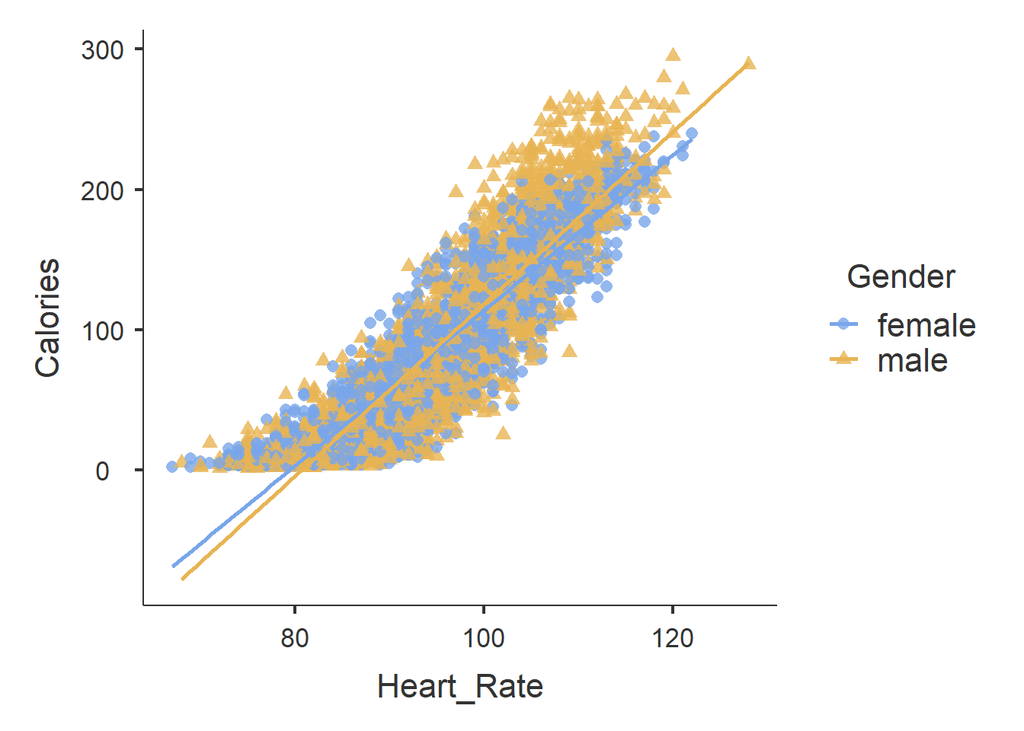

- **Interpretation:** Es besteht ein positiver Zusammenhang zwischen Kalorienverbrauch und Herzfrequenz. Ein linearer Zusammenhang ist fraglich. Damit ist diese Voraussetzung für den Korralationskoeffizienten nach Pearson nicht erfüllt und wir entscheiden für den Rangkorrelationskoeffizienten nach Spearman $r_s$. (**für Nerds:** Wählen Sie unter *Regression Line*: Smooth und Sie erkennen, dass der wahre Zusammenhang einer schwach S-förmig gekrümmten Kurve folgt.)
- **jamovi** > Register *Analyses* > *Regression* > *Correlation Matrix* > Wählen Sie die Variablen `Heart_Rate` und `Calories` aus (für den Korrelationskoeffizienten ist die Reihenfolge irrelevant) > *Correlation Coefficients*: Spearman > *Additional Options*: Häkchen bei *Report significance*.

```
##
##  CORRELATION MATRIX
##
##  Correlation Matrix
##  ───────────────────────────────────────────────────────────
##                                    Heart_Rate    Calories
##  ───────────────────────────────────────────────────────────
##    Heart_Rate    Spearman's rho             —
##                  p-value                    —
##
##    Calories      Spearman's rho     0.9169651            —
##                  p-value           < .0000001            —
##  ───────────────────────────────────────────────────────────
```

- **Es besteht ein signifikanter positiver Zusammenhang zwischen Herzfrequenz und Kalorienverbrauch, $r_s$ = 0.917, p < .0001.**
2. Finden Sie einen linearen Zusammenhang zwischen … Körpertemperatur und Kalorienverbrauch?

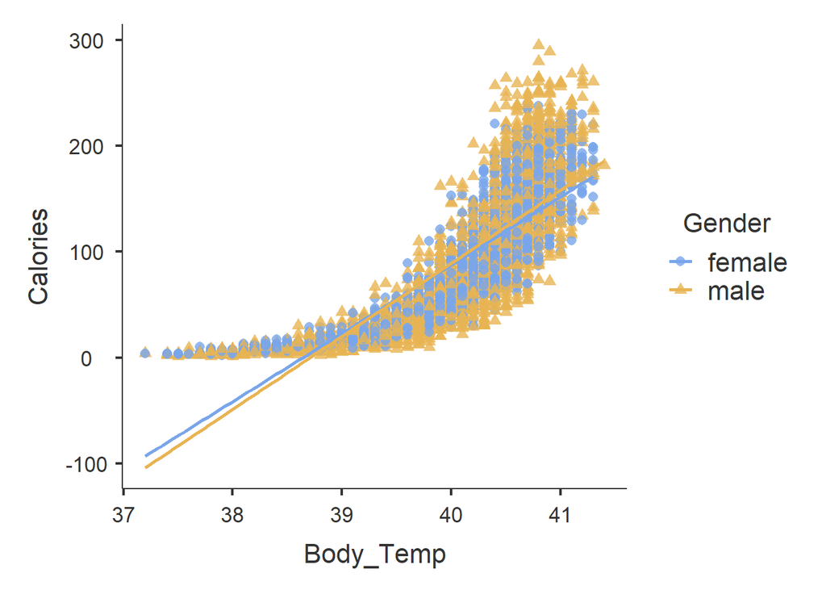

```
##
##  CORRELATION MATRIX
##
##  Correlation Matrix
##  ──────────────────────────────────────────────────────────
##                                   Body_Temp     Calories
##  ──────────────────────────────────────────────────────────
##    Body_Temp    Spearman's rho             —
##                 p-value                    —
##
##    Calories     Spearman's rho     0.9185212            —
##                 p-value           < .0000001            —
##  ──────────────────────────────────────────────────────────
```

- **Es besteht ein signifikanter positiver Zusammenhang zwischen Körpertemperatur und Kalorienverbrauch, $r_s$ = 0.919, p < .0001. Der Zusammenhang ist eindeutig nicht linear.**
3. Finden Sie einen linearen Zusammenhang zwischen … Herzfrequenz und Körpertemperatur?

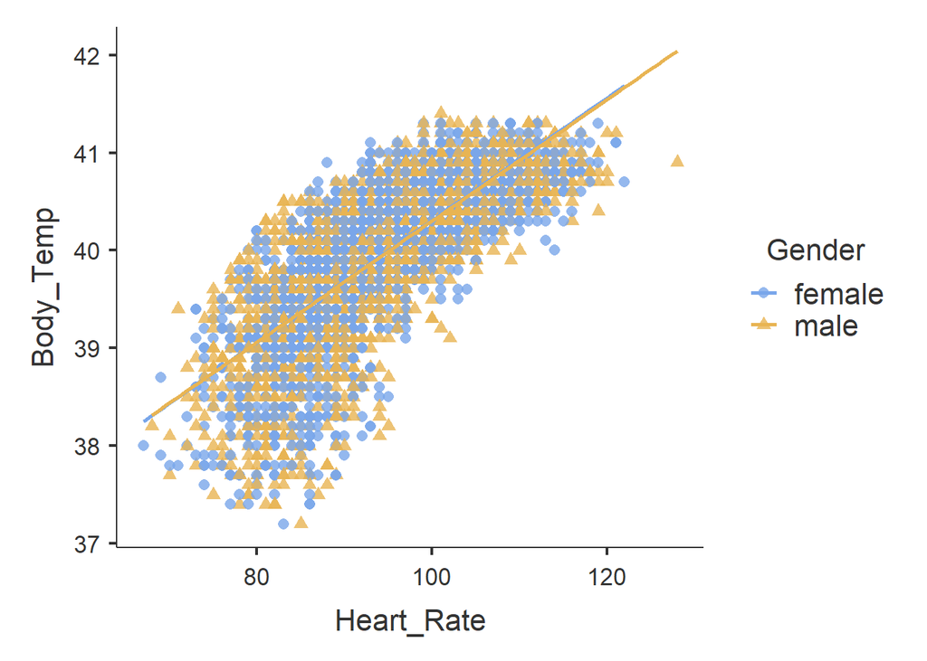

```
##
##  CORRELATION MATRIX
##
##  Correlation Matrix
##  ───────────────────────────────────────────────────────────
##                                    Heart_Rate    Body_Temp
##  ───────────────────────────────────────────────────────────
##    Heart_Rate    Spearman's rho             —
##                  p-value                    —
##
##    Body_Temp     Spearman's rho     0.8144434            —
##                  p-value           < .0000001            —
##  ───────────────────────────────────────────────────────────
```

- **Es besteht ein signifikanter positiver Zusammenhang zwischen Körpertemperatur und Herzfrequenz, $r_s$ = .814, p < .0001. Der Zusammenhang ist eindeutig nicht linear.**
4. Finden Sie einen linearen Zusammenhang zwischen … Alter und Trainingsdauer?

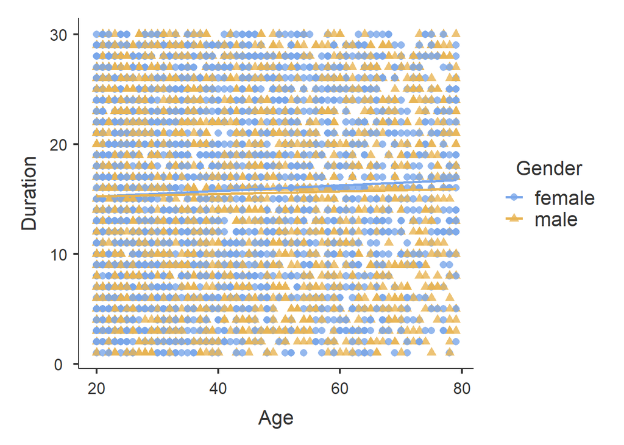

```
##
##  CORRELATION MATRIX
##
##  Correlation Matrix
##  ────────────────────────────────────────────────────────
##                                  Age          Duration
##  ────────────────────────────────────────────────────────
##    Age         Pearson's r               —
##                p-value                   —
##                Spearman's rho            —
##                p-value                   —
##
##    Duration    Pearson's r       0.0366568            —
##                p-value           0.0095350            —
##                Spearman's rho    0.0346048            —
##                p-value           0.0144030            —
##  ────────────────────────────────────────────────────────
```

- **Es besteht kein Zusammenhang zwischen Alter und Trainingsdauer, $r$ = .037, p = .0095; $r_s$ = .035, p = .0144. (Die signifikanten p-Werte sind etwas irritierend, sind jedoch v.a. auf den grossen Stichprobenumfang zurückzuführen.)**
2. Vermutlich besteht ein starker Zusammenhang zwischen der Trainingsintensität und dem Kalorienverbrauch. Können Sie mit aus den gegebenen Variablen eine neue, abgeleitete Variable für Trainingsintensität berechnen?
- Ein mögliches Mass für die Trainingsintensität ist die Herzfrequenz, die mit zunehmender Anstrengung ansteigt und die Trainingsdauer.
- Erstellen Sie in **jamovi** > Register *Data* > *Compute* eine abgeleitete Variable `Intensity = Heart_Rate * Duration`

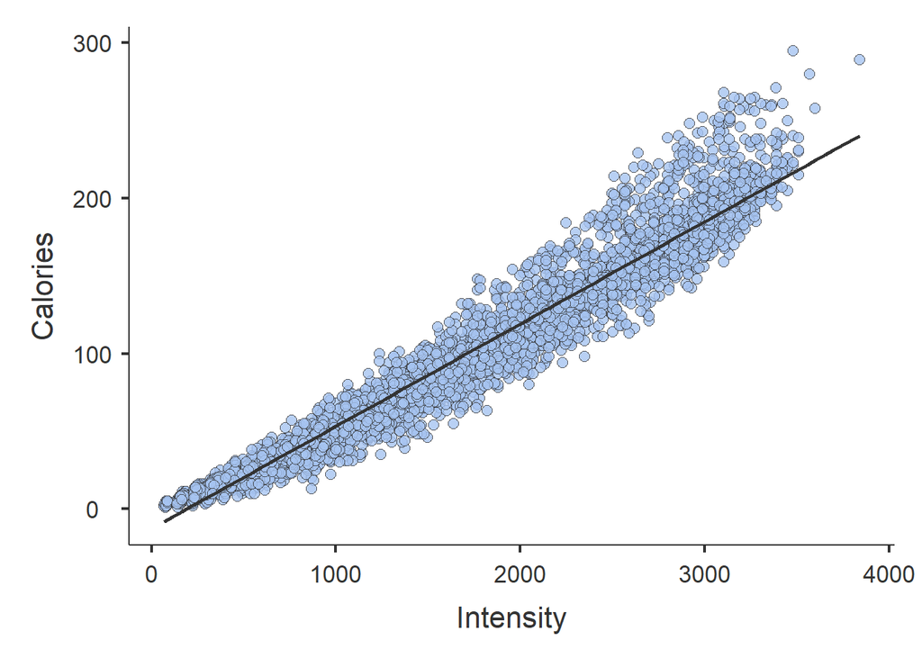

```
##
##  CORRELATION MATRIX
##
##  Correlation Matrix
##  ──────────────────────────────────────────────────────────
##                                   Calories      Intensity
##  ──────────────────────────────────────────────────────────
##    Calories     Pearson's r                —
##                 p-value                    —
##                 95% CI Upper               —
##                 95% CI Lower               —
##                 Spearman's rho             —
##                 p-value                    —
##
##    Intensity    Pearson's r        0.9743146            —
##                 p-value           < .0000001            —
##                 95% CI Upper       0.9756833            —
##                 95% CI Lower       0.9728699            —
##                 Spearman's rho     0.9849117            —
##                 p-value           < .0000001            —
##  ──────────────────────────────────────────────────────────
```

# Übung 7

Fragestellung: Besteht ein Zusammenhang zwischen dem Alter einer Person und ihrer Performance beim 100-Meter-Sprint. Um die Frage zu beantworten, messen wir von 6 Personen das Alter in Jahren, und die Zeit für einen 100-Meter-Sprint in Sekunden. Die Ergebnisse sind im Datensatz `m100.csv` abgelegt.

Codebook: Der Datensatz umfasst 6 Beobachtungseinheiten und 3 Variablen.

| Variable | Beschreibung |
| --- | --- |
| ID | Proband:in, A … F |
| jahre | Alter in Jahren |
| sec | Zeit für 100-m-Sprint in Sekunden |

Laden Sie den Datensatz `m100.csv` in **jamovi** und kategorisieren Sie die Variablen (`jahre` ist continuous-integer).

## Aufgabe

0. Laden Sie den Datensatz `m100.csv` in **jamovi**.
1. Formulieren Sie Ihre Hypothesen.
2. Erstellen Sie ein Streudiagramm und führen Sie eine Korrelationsanalyse durch.
3. Interpretieren Sie ihr Resultat.

## Lösung

1. Formulieren Sie Ihre Hypothesen.
- $H_0: \rho = 0$: Es besteht kein Zusammenhang zwischen dem Alter und Zeit für den 100-Meter-Sprint.
- $H_A: \rho \neq 0$: Es besteht ein Zusammenhang zwischen dem Alter und Zeit für den 100-Meter-Sprint.
2. Erstellen Sie ein Streudiagramm und führen Sie eine Korrelationsanalyse durch.

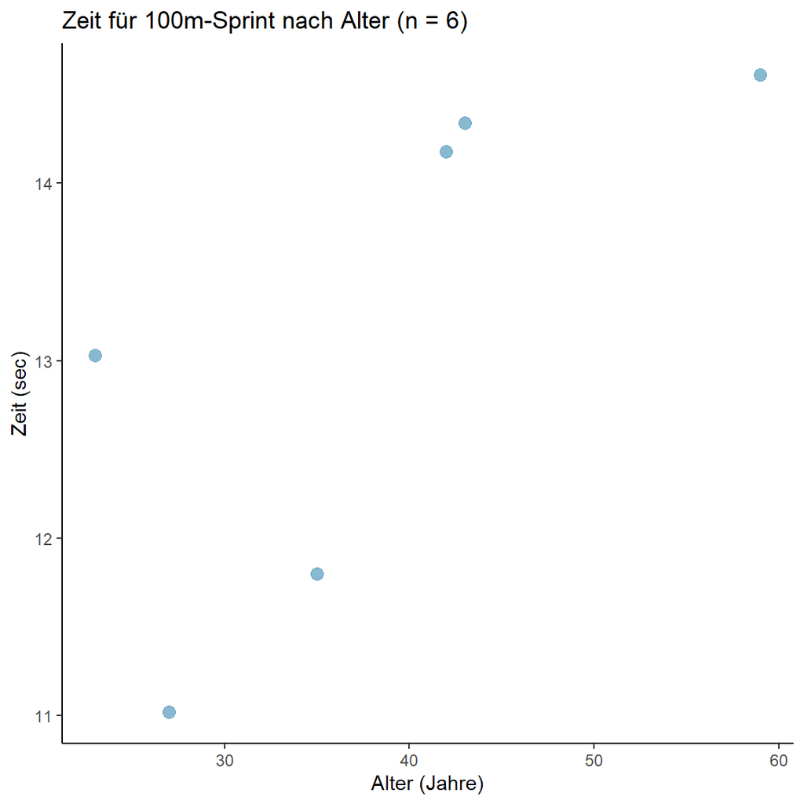

```
##
##  CORRELATION MATRIX
##
##  Correlation Matrix
##  ─────────────────────────────────────────────────────
##                               jahre        sec
##  ─────────────────────────────────────────────────────
##    jahre    Pearson's r               —
##             p-value                   —
##             Spearman's rho            —
##             p-value                   —
##
##    sec      Pearson's r       0.7301807            —
##             p-value           0.0993819            —
##             Spearman's rho    0.8285714            —
##             p-value           0.0583333            —
##  ─────────────────────────────────────────────────────
```

3. Interpretieren Sie ihr Resultat.
- **Die Daten zeigen keinen signifikanten Zusammenhang zwischen Alter und Laufzeit $(r = 0.730, p = 0.099)$. Aus dem Streudiagramm geht nicht eindeutig hervor ob der Zusammenhang zwischen Alter und Laufzeit linear ist. Die Messung der Laufzeit beim jüngsten Läufer ist vermutlich ein Ausreisser. Auch die Berechnung des Rangkorrelationskoeffizienten nach Spearman ergibt keinen signifikanten Zusammenhang zwischen Alter und Laufzeit $(r_s = 0.829, p = 0.058)$.**

# Übung 8

Hier ein Beispiel dafür, dass man mit Korrelationen jeden Unsinn “beweisen” kann.

2020 publizierte Pavlo Blavatskyy eine Studie, in der der Zusammenhang des BMI der Minister von 15 Postsowjet-Staaten und dem Korruptionslevel untersucht wurde. Er ermittelte mit Hilfe von Machine-Learning-Algorithmen anhand von Fotografien der Minister deren BMI und verglich diesen mit 5 Korruptionsindizes [@corruption]. 2021 wurde Blavatskyy der Ig-Nobelpreis [wikipedia](https://de.wikipedia.org/wiki/Ig-Nobelpreis) für diese Publikation verliehen [Improbable Research](https://www.improbable.com/2021-ceremony/winners/).

Für diese Aufgabe wird nur der Korruptionsindex CPI von Transparancy International berücksichtigt (die anderen 4 stehen im Datensatz für eigene Analysen zur Verfügung). *Der CPI 2020 umfasst 180 Länder, die auf einer Skala von 0 (hohes Maß an wahrgenommener Korruption) bis 100 (keine wahrgenommene Korruption) angeordnet werden*. Weltweit erreichen mehr als zwei Drittel aller Länder eine Punktzahl von unter 50 Punkten, das heisst wengier als die Hälfte der möglichen Punktzahl. Der Durchschnitt liegt bei nur 43 Punkten.

Der Index fasst 13 Einzelindizes von 12 unabhängigen Institutionen zusammen und beruht auf Daten aus der Befragung von Expertinnen und Experten, Umfragen sowie weiteren Untersuchungen. Der Korruptionswahrnehmungsindex bezieht sich dabei auf den öffentlichen Sektor und erfasst keine Aktivitäten wie Steuerbetrug, Geldwäsche, illegale Finanzströme oder andere Formen der Korruption im privaten Sektor. [Transparency International](https://www.transparency.de/cpi/)

Laden Sie den Datensatz `corruption.csv` in **jamovi**.

Falls Sie sich für die Fotografien der Minister interessieren, anhand derer der BMI geschätzt wurde finden Sie diese [hier](https://onlinelibrary.wiley.com/action/downloadSupplement?doi=10.1111%2Fecot.12259&file=ecot12259-sup-0001-Appendix.docx).

## Aufgabe

Fragestellung: Besteht ein Zusammenhang zwischen dem BMI von Ministern ehemaliger Sowjet-Staaten und dem Korruptionsindex CPI *Corruption_Perceptions_Index_2017*.

0. Laden Sie den Datensatz `corruption.csv` in jamovi.
1. Formulieren Sie Ihre Hypothesen.
2. Erstellen Sie ein Streudiagramm und führen Sie eine Korrelationsanalyse durch.
3. Interpretieren Sie ihr Resultat.

Codebook (abgekürzt): Der Datensatz umfasst 7 Variablen zu 15 Ländern

| Variable | Beschreibung |
| --- | --- |
| Country | Postsowjet-Staat |
| Median_BMI | Geschätzter durchschnittlicher BMI der Minister:innen (Median) |
| Corruption_Perceptions_Index_2017 | Korruptionsindex CPI von Transparency International |
| … | weitere Korruptionsindizes |

## Lösung

1. Formulieren Sie Ihre Hypothesen.
- $H_0: \rho = 0$: Es besteht kein Zusammenhang zwischen dem BMI der Minister und dem Korruptionsindex
- $H_A: \rho \neq 0$: Es besteht ein Zusammenhang zwischen dem BMI der Minister und dem Korruptionsindex
2. Erstellen Sie ein Streudiagramm und führen Sie eine Korrelationsanalyse durch.

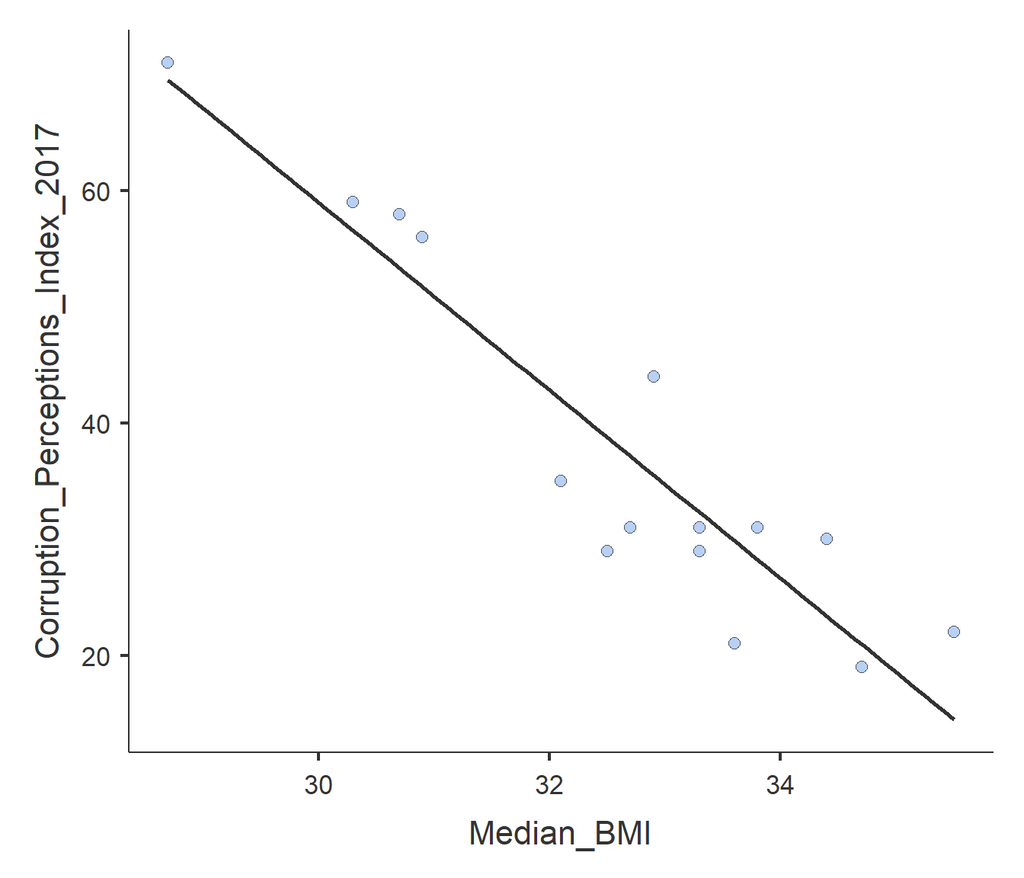

```
##
##  CORRELATION MATRIX
##
##  Correlation Matrix
##  ────────────────────────────────────────────────────────────────────────────────────────────────────────
##                                                         Median_BMI    Corruption_Perceptions_Index_2017
##  ────────────────────────────────────────────────────────────────────────────────────────────────────────
##    Median_BMI                           Pearson's r              —
##                                         p-value                  —
##                                         95% CI Upper             —
##                                         95% CI Lower             —
##
##    Corruption_Perceptions_Index_2017    Pearson's r     -0.9267462                                    —
##                                         p-value          0.0000007                                    —
##                                         95% CI Upper    -0.7890977                                    —
##                                         95% CI Lower    -0.9757729                                    —
##  ────────────────────────────────────────────────────────────────────────────────────────────────────────
```

3. Interpretieren Sie ihr Resultat.
- **Die Daten zeigen einen signifikanten linearen Zusammenhang zwischen dem BMI und dem Korruptionsindex. Nimmt der BMI zu, sinkt der Korrupitionsindex (und verschlechtert sich damit). Mit $p$ = -0.927 [-0.976, -0.789], p < .0001 ist der Zusammenhang sehr stark.**
- Je höher der Korruptionsindex, desto geringer ist die Korruption, d.h. es besteht ein negativer Zusammenhang zwischen Korruptionsindex und Korruption. Die Aussage ist wenig intuitiv und wird besser verständlich, wenn wir den Corruption_Perceptions_Index_2017 transformieren, so dass ein Korruptionsindex von 0 keiner Korruption und ein Korruptionsindex von 100 maximaler Korruption entspricht:
- **jamovi** > Register *Data* > *Compute* > `Corruption_Perceptions_Index_2017_t` = 100 - Corruption_Perceptions_Index_2017

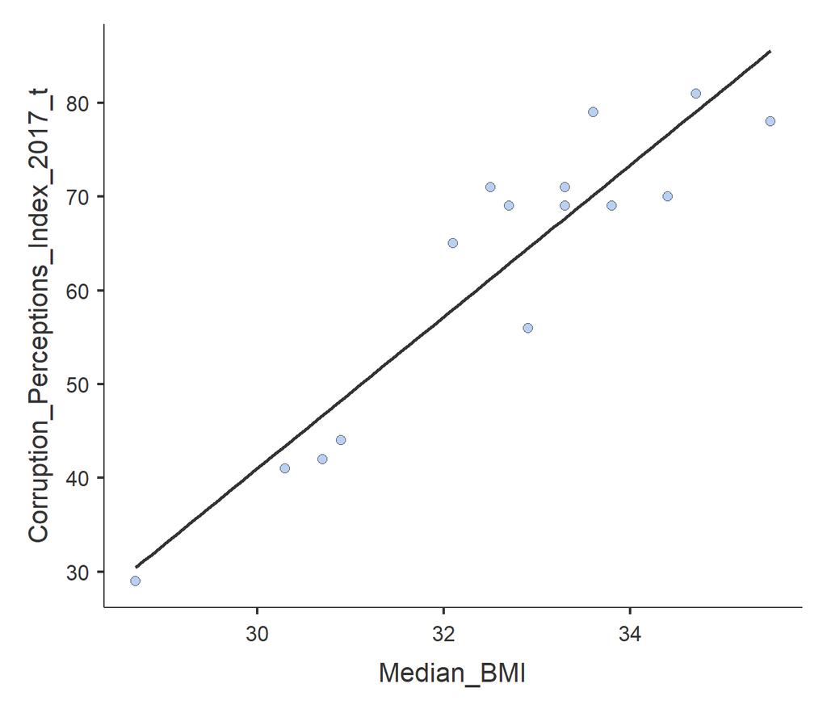

```
##
##  CORRELATION MATRIX
##
##  Correlation Matrix
##  ────────────────────────────────────────────────────────────────────────────────────────────────────────────
##                                                           Median_BMI    Corruption_Perceptions_Index_2017_t
##  ────────────────────────────────────────────────────────────────────────────────────────────────────────────
##    Median_BMI                             Pearson's r              —
##                                           p-value                  —
##                                           95% CI Upper             —
##                                           95% CI Lower             —
##
##    Corruption_Perceptions_Index_2017_t    Pearson's r      0.9267462                                      —
##                                           p-value          0.0000007                                      —
##                                           95% CI Upper     0.9757729                                      —
##                                           95% CI Lower     0.7890977                                      —
##  ────────────────────────────────────────────────────────────────────────────────────────────────────────────
```

- Die Aussage dieser Grafik ist intuitiv besser verständlich: Es besteht ein starker positiver linearer Zusammenhang zwischen BMI und Korruption; mit zunehmendem BMI der Minister steigt auch die Korruption im Land. Der Korrelationskoeffizient wird durch diese Transformation nicht beeinflusst.
- Anmerkung: Die Art der Fragestellung, die Methodik der Studie und die Schlussfolgerung sind äusserst fragwürdig. Die Studie von Pavlo Blavatskyy wurde in der Presse und von anderen Forscher:innen massiv kritisiert, z.B. [hier](https://sites.temple.edu/klugman/2020/08/15/that-fat-politician-study/).

# Übung 9

Ist die Impfung gegen COVID-19 wirksam? Um diese Frage zu beantworten verwenden wir den Datensatz `impfquote_bag.csv` mit den Variablen `Impfquote`(% der kantonalen Bevölkerung, die mindestens einmal geimpft sind) und `inzsumTotal_last7d` (Covid-19 7-Tage-Inzidenz pro 100’000). Die Variable `geoRegion` gibt die jeweiligen Kantone an. (Die Daten stammen vom BAG. Sie wurden von Marius Brülhart aufbereitet und von [Der Bund](https://www.derbund.ch/dort-wo-viele-geimpft-sind-gibt-es-weniger-ansteckungen-115502688268) online publiziert).

## Aufgabe

1. Formulieren Sie eine Fragestellung.
2. Formulieren Sie die Hypothesen.
3. Erstellen Sie ein Streudiagramm.
4. Berechnen Sie den Korrelationskoeffizienten nach Pearson.
5. Interpretieren Sie ihr Resultat.

## Lösung

1. Formulieren Sie eine Fragestellung: *Besteht ein Zusammenhang zwischen der kantonalen Impfquote und der kantonalen 7-Tage-Inzidenz an Covid-19-Infektionen.*
2. Formulieren Sie die Hypothesen.
- $H_0: \rho = 0$ Es gibt keinen Zusammenhang zwischen der kantonalen Impfquote und der kantonalen 7-Tage-Inzidenz.
- $H_A: \rho \neq 0$ Es gibt einen Zusammenhang zwischen der kantonalen Impfquote und der kantonalen 7-Tage-Inzidenz.
3. Erstellen Sie ein Streudiagramm.
4. Berechnen Sie den Korrelationskoeffizienten nach Pearson.

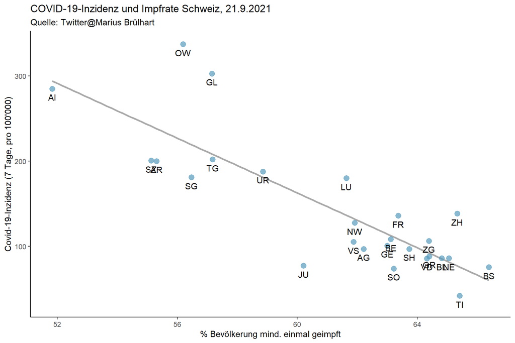

```
##
##  CORRELATION MATRIX
##
##  Correlation Matrix
##  ──────────────────────────────────────────────────────────────────────────
##                                          Impfquote     inzsumTotal_last7d
##  ──────────────────────────────────────────────────────────────────────────
##    Impfquote             Pearson's r              —
##                          p-value                  —
##                          95% CI Upper             —
##                          95% CI Lower             —
##
##    inzsumTotal_last7d    Pearson's r     -0.8323732                     —
##                          p-value          0.0000001                     —
##                          95% CI Upper    -0.6567817                     —
##                          95% CI Lower    -0.9223423                     —
##  ──────────────────────────────────────────────────────────────────────────
```

5. Interpretieren Sie ihr Resultat
- **Die Daten zeigen einen signifikanten linearen Zusammenhang zwischen kantonaler Impfquote und Covid-19 7-Tage-Inzidenz. Es besteht ein negativer Zusammenhang: Mit zunehmender Impfquote nimmt die Covid-19-Inzidenz ab ($p$ = -0.832 [-0.922, -0.657], p < 0.0001)**
- Haben wir damit bewiesen, dass die Impfung wirksam ist? Nein! Auch wenn der Zusammenhang stark und signifikant ist, kann anhand dieser Analyse kein kausaler Zusammenhang zwischen Impfquote und Covid-19-Inzidenz bewiesen werden werden! Die Korrelation kann jedoch einen Hinweis für einen Kausalzusammenhang geben.